# Task 2: Classification: Predict which Brand of Products Customers Prefer

```r
#View(df_validation)
# Update Data Types
df_validation$"elevel" <- as.factor(df_validation$"elevel")
df_validation$"car" <- as.factor(df_validation$"car")
df_validation$"zipcode" <- as.factor(df_validation$zipcode)
df_validation$brand<-as.factor(df_validation$brand)
Get_to_know_data(df_validation)
```

```
[1] "GET TO KNOW:  df_validation"
[1] "fetching summary..."
     salary            age        elevel        car          zipcode         credit       brand
 Min.   : 20000   Min.   :20.00   0: 989   19     : 278   4      : 592   Min.   :     0   0:4937
 1st Qu.: 52590   1st Qu.:35.00   1: 988   18     : 264   7      : 569   1st Qu.:122311   1:  63
 Median : 86221   Median :50.00   2:1017   16     : 262   5      : 565   Median :250974
 Mean   : 85794   Mean   :49.94   3:1000   8      : 260   8      : 560   Mean   :249546
 3rd Qu.:118535   3rd Qu.:65.00   4:1006   11     : 259   1      : 549   3rd Qu.:375653
 Max.   :150000   Max.   :80.00            5      : 257   3      : 549   Max.   :500000
                                           (Other):3420   (Other):1616
[1] "fetching data structure..."
Classes ‘spec_tbl_df’, ‘tbl_df’, ‘tbl’ and 'data.frame':    5000 obs. of  7 variables:
 $ salary : num  150000 82524 115647 141443 149211 ...
 $ age    : num  76 51 34 22 56 26 64 50 26 46 ...
 $ elevel : Factor w/ 5 levels "0","1","2","3",..: 2 2 1 4 1 5 4 4 3 4 ...
 $ car    : Factor w/ 20 levels "1","2","3","4",..: 3 8 10 18 5 12 1 9 3 18 ...
 $ zipcode: Factor w/ 9 levels "0","1","2","3",..: 4 4 3 3 4 2 3 1 5 7 ...
 $ credit : num  377980 141658 360980 282736 215667 ...
 $ brand  : Factor w/ 2 levels "0","1": 2 1 2 2 2 2 2 2 2 1 ...
 - attr(*, "spec")=
  .. cols(
  ..   salary = col_double(),
  ..   age = col_double(),
  ..   elevel = col_double(),
  ..   car = col_double(),
  ..   zipcode = col_double(),
  ..   credit = col_double(),
  ..   brand = col_double()
  .. )
NULL
```

```r
# transform the dataset using the parameters
df_validation_preprocesssed<- predict(preprocessParams, df_validation)
Get_to_know_data(df_validation_preprocesssed)
```

```
[1] "GET TO KNOW:  df_validation_preprocesssed"
[1] "fetching summary..."
     salary            age        elevel        car          zipcode         credit       brand
 Min.   :0.5303   Min.   :1.137   0: 989   19     : 278   4      : 592   Min.   :0.0000   0:4937
 1st Qu.:1.3945   1st Qu.:1.989   1: 988   18     : 264   7      : 569   1st Qu.:0.8423   1:  63
 Median :2.2863   Median :2.841   2:1017   16     : 262   5      : 565   Median :1.7283
 Mean   :2.2750   Mean   :2.838   3:1000   8      : 260   8      : 560   Mean   :1.7185
 3rd Qu.:3.1431   3rd Qu.:3.694   4:1006   11     : 259   1      : 549   3rd Qu.:2.5869
 Max.   :3.9775   Max.   :4.546            5      : 257   3      : 549   Max.   :3.4433
                                           (Other):3420   (Other):1616
[1] "fetching data structure..."
Classes ‘spec_tbl_df’, ‘tbl_df’, ‘tbl’ and 'data.frame':    5000 obs. of  7 variables:
 $ salary : num  3.98 2.19 3.07 3.75 3.96 ...
 $ age    : num  4.32 2.9 1.93 1.25 3.18 ...
 $ elevel : Factor w/ 5 levels "0","1","2","3",..: 2 2 1 4 1 5 4 4 3 4 ...
 $ car    : Factor w/ 20 levels "1","2","3","4",..: 3 8 10 18 5 12 1 9 3 18 ...
 $ zipcode: Factor w/ 9 levels "0","1","2","3",..: 4 4 3 3 4 2 3 1 5 7 ...
 $ credit : num  2.603 0.976 2.486 1.947 1.485 ...
 $ brand  : Factor w/ 2 levels "0","1": 2 1 2 2 2 2 2 2 2 1 ...
 - attr(*, "spec")=
  .. cols(
  ..   salary = col_double(),
  ..   age = col_double(),
  ..   elevel = col_double(),
  ..   car = col_double(),
  ..   zipcode = col_double(),
  ..   credit = col_double(),
  ..   brand = col_double()
  .. )
NULL
```

```r
print("Testing Set:")
```

```
[1] "Testing Set:"
```

```r
prediction <- predict(rfFit_manualgrid_1, df_validation_preprocesssed)
confusionMatrix(prediction, df_validation_preprocesssed$brand)
```

```
Confusion Matrix and Statistics

          Reference
Prediction    0    1
         0 1854    5
         1 3083   58

               Accuracy : 0.3824
                 95% CI : (0.3689, 0.396)
    No Information Rate : 0.9874
    P-Value [Acc > NIR] : 1

                  Kappa : 0.0118
 Mcnemar's Test P-Value : <2e-16

            Sensitivity : 0.37553
            Specificity : 0.92063
         Pos Pred Value : 0.99731
         Neg Pred Value : 0.01847
             Prevalence : 0.98740
         Detection Rate : 0.37080
   Detection Prevalence : 0.37180
      Balanced Accuracy : 0.64808

       'Positive' Class : 0
```

3. After making the predictions using the test set use postResample() to assess the metrics of the new predictions compared to the Ground Truth (see the resources for more information)

```r
postResample(prediction, df_validation_preprocesssed$brand)
```

```
  Accuracy      Kappa
0.38240000 0.01179155
```

4. Did something interesting happen here? If so, be prepared to explain why!

The accuracy and kappa scores are quite terrible on the validation set. Digging into the data a bit more, we see below the summary of the distributions for brand class in the training-test set and the validation set. You can see the validation set has a huge amount of “0” brand classes. Based on this fact, and the fact that the file is labeled “incomplete”, it is likely that this data set was simply populated with 0’s for the unkown brands, thus these labels are likely not real. It is possilbe that this data set is composed of data which sits outside of the parameter space which was trained, and thus the model is relying on extrapolation. This could be confirmed by simply plotting all the data and seeing if the validatioan data sits in the same parameter space as the train-test data, however we will skip this since the evidence seems quite strong that the validation data is just composed of many incorrectly labeled brand IDs.

```r
"Train-test set brand distribution:"
```

```
[1] "Train-test set brand distribution:"
```

```r
summary(df$brand)
```

```
   0    1
3744 6154
```

```r
"Validation set brand distirbution:"
```

```
[1] "Validation set brand distirbution:"
```

```r
summary(df_validation_preprocesssed$brand)
```

```
   0    1
4937   63
```

5. Use the summary() function and your prediction object to learn how many individuals are predicted to prefer Sony and Acer.

```r
summary(prediction)
```

```
   0    1
1859 3141
```

6. Explain the importance of each feature used in the model and support it with quantitative evidence.

Below we see the ten most important variables (out of 34) composing the random forest model. Here, we see that salary, age, then credit are the highest contributing factors to determining brand.

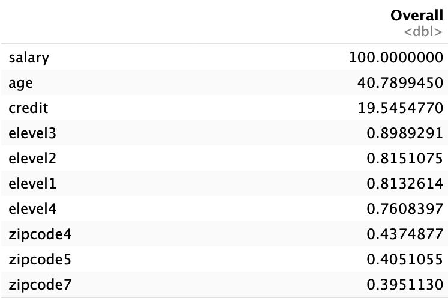

‘random_forest_variable_importance_table.png’

We can get a more intuitive feel for the meaning behind these variable impact values by plotting a series of scatter plots. Viewing the brand vs. salary plot, we see brand 1 (Sony) customers have a higher mean salary than brand 0 (Acer) customers. Vieing the brand and credit vs. age plots, we don’t see anything noticable, however by plotting salary vs age by brand (as color), we can visualize a deeper structure in the age vs. salary data, whic the model has learned to represent/map via decision trees. You could likely visualize this even more clearly by creating a dummy data set that sweeps the random forest model over the entire mapped parameter space and plotting the prediction in color, however we won’t go into such detail here. Finally, we also see a weaker, but significant relationship in the salary vs. credit by brand plot, which also inuitivaley makes sense from the model’s variable importance table.

```r
subplot_cols = 2
subplot_rows = 3
par(mfrow=c(subplot_rows,subplot_cols))
plot(df$brand,df$salary, xlab = 'brand', ylab = 'salary')
plot(df$brand,df$age, xlab = 'brand', ylab = 'age')
```

```r
plot(df$brand,df$credit, xlab = 'brand', ylab = 'credit')
plot(df$salary,df$age, xlab = 'salary', ylab = 'age', type="p",pch=20,col=df$brand)
```

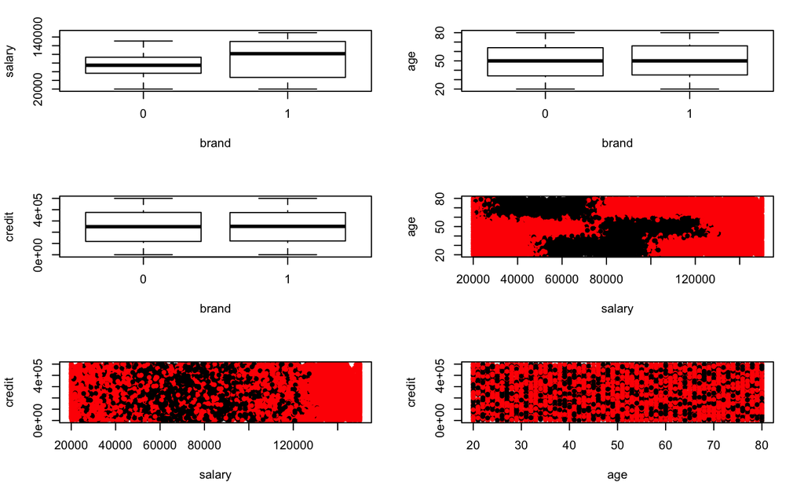

```r
plot(df$salary,df$credit, xlab = 'salary', ylab = 'credit', type="p",pch=20,col=df$brand)
plot(df$age,df$credit, xlab = 'age', ylab = 'credit', type="p",pch=20,col=df$brand)
```

7. Write your Customer Brand Preferences Report.

## Customer Brand Preferences Report

### Introduction

In this report, we analyze & model the market research survey data from existing customers. This data was compiled by a market research firm hired by the Blackwell Electronics sales team engaged. In this survey, the primary objective was to document which of two brands of computers customers prefered based on the customer’s characteristics, including salary, age, education level (elevel), type of car, zipcode, and available credit. Here, we analyze several models which may be used to predict customer brand preference based on these features. Using our optimal model, we predict the customer brand preferences for a subset of the data for which the survey information was incorrectly entered.

### Data Structure & Preprocessing

Prior to divinig into the details of the models trained on the data, it is important to understand the structure and the preprocessing steps we carried out to before model training. This data set (“CompleteResponses.csv”) was composed of ~10,000 samples (rows) with nominal/categorical/factor data columns, as well as continuous numerical data columns. Specifically, the features such as education level, type of car, and zipcode, as well as the label of interest, brand, were numerically encoded categorical integers. The table below summarizes the numerical keys associated with the categorical string values

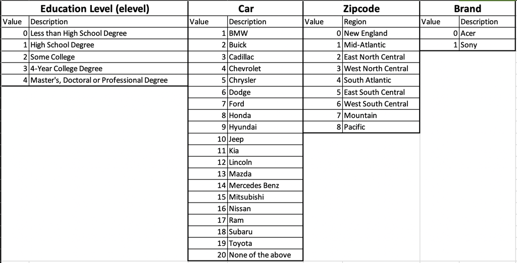

After specifying these features and the brand label as factors, we performed feature scaling on the continuous data columns (credit, salary, and age). This ensured that none of these features impact the model fitting purely based on the relative scale/magnitude of their basic unit. More specifically, the preprocess scaling parameters were generated using the code below via the cerat package preProcess function.

```r
preprocessParams <- preProcess(df, method=c("scale"))
```

Following the continuos data feature scaling, we tested the features to determine if any values were missing from the data frame. It was determined that there were no missing values.

Finally, we performed a 75%-25% train-test split on the preprocessed data frame using the code below:

```r
y <- df_preprocesssed$brand
inTraining <- createDataPartition(y, p = .75, list = FALSE)
training <- df_preprocesssed[inTraining,]
testing <- df_preprocesssed[-inTraining,]
```

### Training & Testing the Models

With the data preprocessed and split into training and testing set, we went on to evaluate two different classification models: (1) C5.0 decision tree and (2) Random Forest. In both models we used 10 fold cross validation, however for the C5.0 decision tree we used an automatic tuning grid, while for the random forest we evaluated a manual tuning grid composed of mtry = 1, 2, 3, 4, 5, where mtry represents the number of variables randomly sampled as candidates at each split. For the C5.0 decision tree, we also defined the tune length hyperparameter to be equal to 2.

Following training of both models, we analyzed the performance of each model by computing the accuracy and kappa on three data partitions: (1) the entire training + test set, (2) the training set alone, and (3) the testing set alone. The table below summarizes the results.

[figure not shown]

models_accuracy_kappa_table

Aside from the kappa and accuracy scores, it is interesting to note that the decision tree put extremely high weights on salary and age alone, while the random forest put the highest weights on those two parameters as well, but also put non-zero weights on the various other features/classes. The relative weights we are refering to here are from the variable importance tables generated for each model. Below we see the ten most important variables/features for each model.

C5.0 Decision Tree Variable Importance:

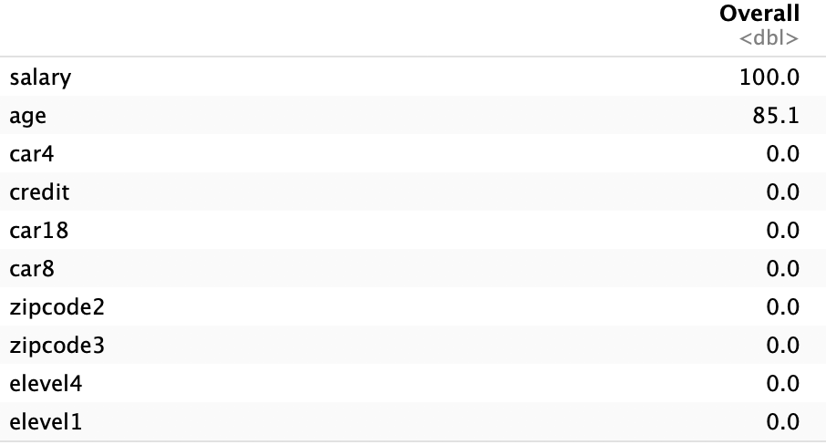

Random Forest Variable Importance:

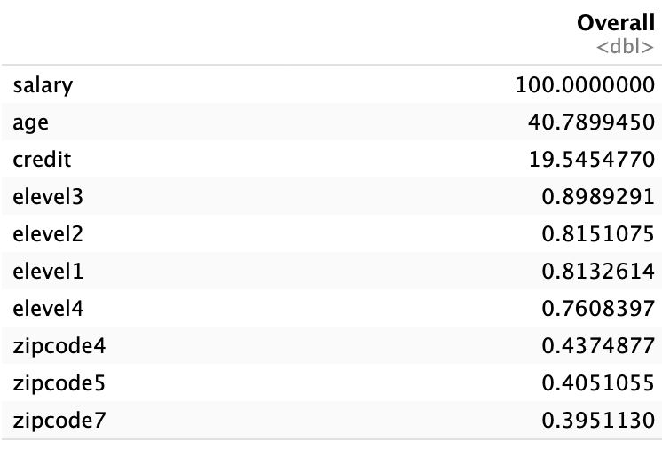

### Predicting Incomplete Survey Brands

Using the trained random forest model, we performed brand predictions on the incomplete survey data set, after it had been passed throug the same preprocess scalar transformation we used on the trianing set. These predictions could be used to update the incomplete survey data with the most likely brand class, overall though, we can get a sense of how incomplete the survey data actually was by considering the distribution of brands in the original data set (i.e. incorrect/incomplete labels), compared to the predicted labels. Specifically, in the original data set, ~5,000 customers were labeled as prefering Acer (0), while only 63 were labeled as prefering Sony (1). This alone seems likely an extremely assymetric distribution from a random sample of users. In contrast to this, the random forest model predicted ~2,000 customers prefer Acer and ~3,000 prefer Sony.

### Illuminating the Model Prediction Logic

To gain a more intuitivae understanding of why and how the model prediction operated, we plotted a series of scatter plots representing the top 3 most heavily weighted features vs. the brand label from the original unprocessed train-test set. The results are shown below:

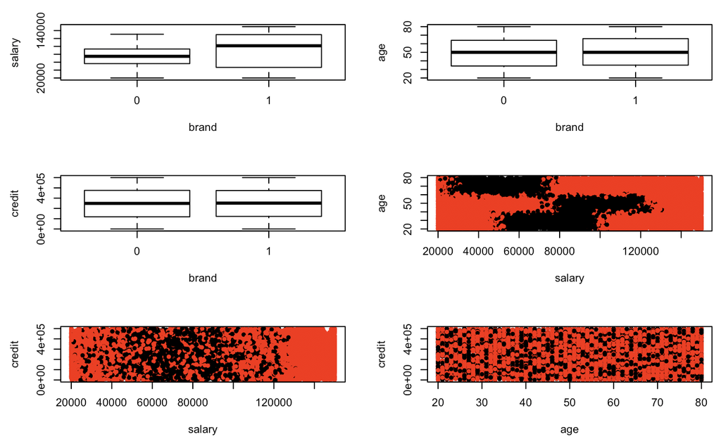

‘scatter_plots’

Viewing the brand vs. salary plot, we see brand 1 (Sony) customers have a higher mean salary than brand 0 (Acer) customers. Vieing the brand and credit vs. age plots, we don’t see anything noticable, however by plotting salary vs age by brand (as color, with black being Acer and red being Sony), we can visualize a deeper structure in the age vs. salary data, which the model has learned to represent/map via decision trees. Finally, we also see a weaker, but significant relationship in the salary vs. credit by brand plot, which also inuitivaley makes sense from the model’s variable importance table.